# Part 2

## V. Cluster Analysis: Hard Clustering into K Clusters

In the preceding section we choose *K=5* as our ideal number of clusters based on the basis of set of internal validation criteria as well as our sense of judgment about the clusters. Next, for each of star ratings viz. neutral , low and high we have performed clustering operation for K=5 leading to the creation of 5 independent clusters for each of the above category.

To reiterate, we have used NMF as our clustering as well as dimensionality reduction algorithm. Hence we essentially have 5 clusters or 5 dimensions for each of the 3 star ratings.

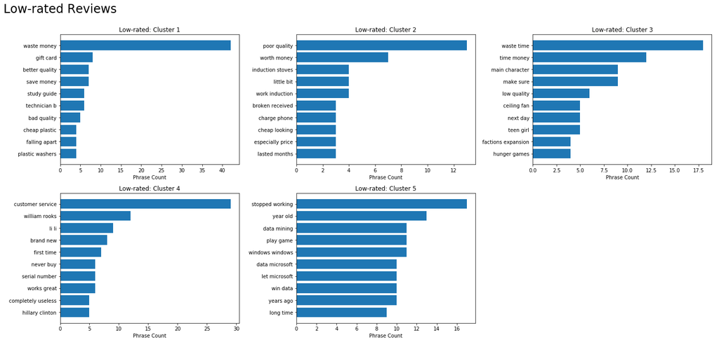

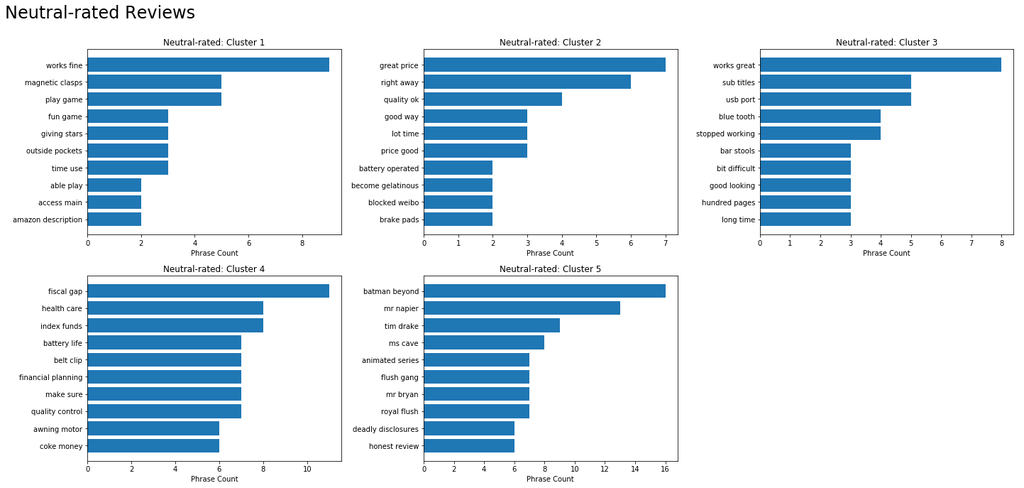

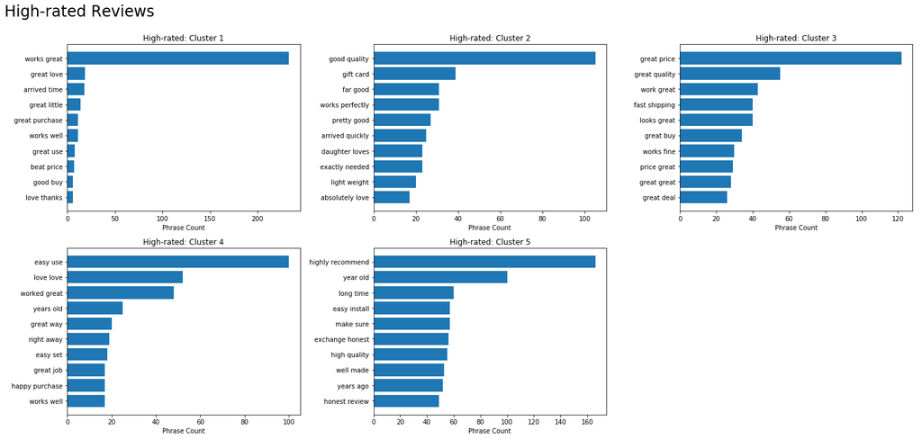

```python
print()
for i in ratings:
    fig, ((ax1, ax2, ax3), (ax4, ax5, ax6)) = plt.subplots(2, 3,
                                                           figsize=(20, 10))
    fig.suptitle("{}-rated Reviews".format(i), x=0, y=.95,
                 horizontalalignment='left', verticalalignment='top',
                 fontsize = 24)
    for k, ax in zip(set(predict[i]), (ax1, ax2, ax3, ax4, ax5)):
        cluster = reviews[i][predict[i]==k]
        word_2 = ngrams(cluster, 2, 10)
        ax.barh(list(word_2.keys())[::-1], list(word_2.values())[::-1])
        ax.set_xlabel("Phrase Count")
        ax.set_title("{}-rated: Cluster {}".format(i, k+1))
    ax6.set_axis_off()
    fig.tight_layout(rect=[0, 0, 1, 0.9])
```

```python
cluster_labels = dict()
for i in ratings:
    labels = dict()
    for k in set(predict[i]):
        cluster = reviews[i][predict[i]==k]
        labels[k] = list(ngrams(cluster, 2, 1).keys())[0]
    cluster_labels[i] = labels

for i in ratings:
    print()
    print("{}-rated Clusters".format(i))
    print(list(cluster_labels[i].values()))
```

```
Low-rated Clusters
['waste money', 'poor quality', 'waste time', 'customer service', 'stopped working']

Neutral-rated Clusters
['works fine', 'great price', 'works great', 'fiscal gap', 'batman beyond']

High-rated Clusters
['works great', 'good quality', 'great price', 'easy use', 'highly recommend']
```

**Discussion of the above results:**

In the above section, we have clustered each of the 3 star ratings into 5 independent clusters. The most frequent words for each of the 5 clusters have been correspondingly plotted.

**Low-rated Customers:**

As seen from above, we have 5 clusters under this category and the most frequent bi-gram is printed out for each of the 5 clusters. It is specially important to note that each of our clusters within a star rating actually represents a customer and his specific requirements. For eg: Cluster 1 has **"waste money"** as the most frequent bi-gram highlighting the fact that this set of customer are price sensitive Cluster 4 : has **"customer service"** as the most frequent bi-gram suggesting that this set of customers value seamless customer service.

**Neutral-rated Customers:**

As seen from above, we have 5 clusters under this category and the most frequent bi-gram is printed out for each of the 5 clusters. It is interesting to note that we don't get clearly defined clusters under this category compared to our Low and High rated category. This result is expected since the neutral rated customers will be reserved/diplomatic in their opinions about the product.

**High-rated Customers:**

### 5. Visualization of Clusters

The clusters have been visualized using the T-SNE method:

**T-SNE:**

t-Distributed Stochastic Neighbor Embedding (t-SNE) is a state of the art technique to visualize the data in two dimensions. This is specially useful for non-linear data. It is important to understand that t-SNE is not a dimensionality reduction algorithm but just a visual aid for plotting in two dimensions. The time complexity of T-SNE is $O(n^2)$ hence it is computationally expensive

**Plotting Clusters using t-SNE:**

Based on the internal validation criteria viz. Calinski-Harabasz Index, Intra-Inter Cluster Distance and the Silhouette score we selected number of clusters as 5.

While the internal validation criteria help us to get the optimal number of clusters, in literature there is no hard and fast rule to meticulously follow them and the choice of K ultimately boils down as to for which K's our cluster make the most sense. Data Science is an art and the choice of K is certainly accentuates the above point. For this reason,quite a few number of iterations must be used before we finally settle down on our optimal value of K

At this point I would like to highlight that our t-SNE plots show some intersection between the clusters. The reason for this is that since our data is highly non-linear any two-dimensional representation would not lead to immaculate visualizations showing separation between the clusters. Hence the reader is advised to keep these things in mind before proceeding to the next section

```python
from sklearn.manifold import TSNE
from PIL import Image
```

```python
tsne = {i : TSNE(random_state=1208).fit_transform(nmf_transform[i]) for i in ratings}
```

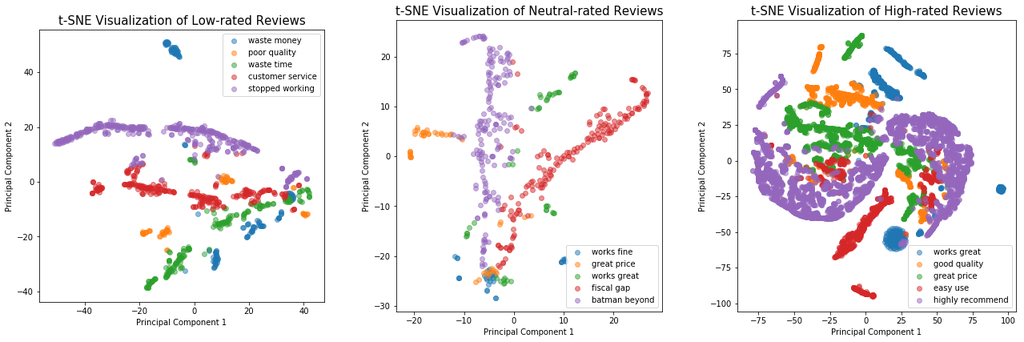

```python
fig, axs = plt.subplots(1, 3, figsize=(18,6))

for i, ax in zip(ratings, axs):
    for cluster in set(predict[i]):
        x = tsne[i][:, 0][predict[i]==cluster]
        y = tsne[i][:, 1][predict[i]==cluster]
        ax.scatter(x, y, marker='o', alpha=0.5,
               label=cluster_labels[i][cluster])
    ax.set_aspect('equal', adjustable='box')
    ax.legend(loc='best')
    ax.set_xlabel('Principal Component 1')
    ax.set_ylabel('Principal Component 2')
    ax.set_title('t-SNE Visualization of {}-rated Reviews'.format(i),
                 fontsize=15);
fig.tight_layout()
```

## V. Results and Insights

This project has proven the viability of using Clustering in extracting themes from amazon.com customer reviews. Below are visualizations of each of the 5 clusters formed per review rating. It may be seen that each cluster is comprised of descriptive words representative of a specific aspect regarding product quality, customer service, and customer satisfaction.

Low rated and High Rated reviews provide high context with respect to the rating system utilized by amazon.com.

Clusters under High Rated reviews provide much insight into specific aspects of how customers perceive value:

- Convenience
- Price/Value for Money
- Shipping Time/Ease of returns
- Product quality
- Product commendations

Results show that user reviews are a rich source of data for deriving user behaviour and their underlying values as consumers.

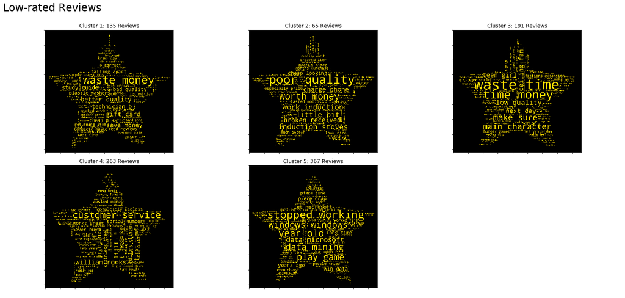

[figure not shown]

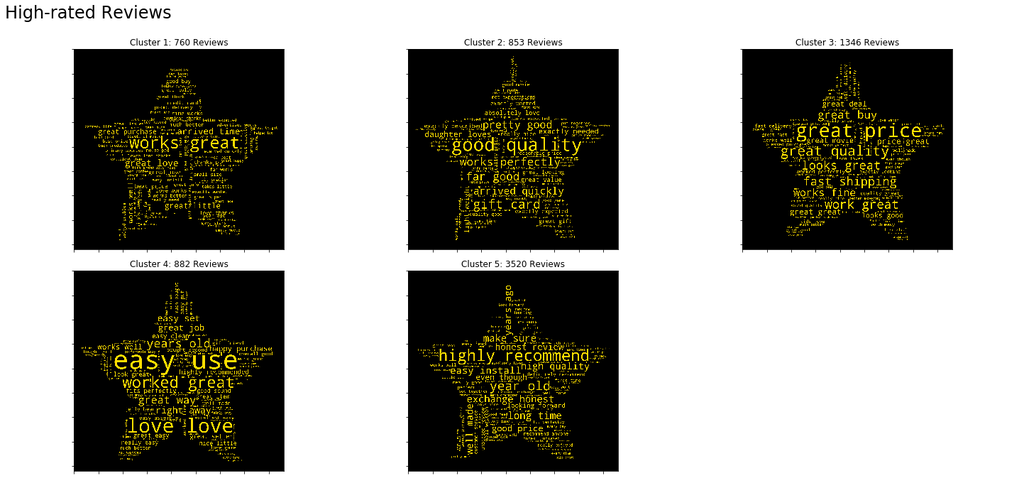

```python
print()

mask = np.array(Image.open('Star.jpg'))
for i in ratings:
    fig, ((ax1, ax2, ax3), (ax4, ax5, ax6)) = plt.subplots(2, 3,
                                                           figsize=(20, 10))
    fig.suptitle("{}-rated Reviews".format(i), x=0, y=.95,
                 horizontalalignment='left', verticalalignment='top',
                 fontsize = 24)
    for k, ax in zip(set(predict[i]), (ax1, ax2, ax3, ax4, ax5)):
        cluster = reviews[i][predict[i]==k]
        word_2 = ngrams(cluster, 2, 100)
        wordcloud = WordCloud(width=800, height=800,
                background_color='black',
                mask=mask, font_step=3,
                color_func=lambda *args, **kwargs: (255,223,0),
                stopwords=STOPWORDS,
                ).generate_from_frequencies(word_2)
        ax.set_title('Cluster {}: {} Reviews'.format(k+1, len(cluster)))
        ax.imshow(wordcloud)
        ax.set_yticklabels([]); ax.set_xticklabels([])
    ax6.set_axis_off()
    fig.tight_layout(rect=[0, 0, 1, 0.9])
```

## VI. Recommendations:

- The authors recommend to promote clustering methods to businesses and organizations reliant on transparent communinication.
- Customer Relationship Management modules may utilize insights from clustering methods to
  - Appropriately Segment & Target Existing Clients with specific needs
  - Immediately identify and manage customer issues prior to lodging of official complaints
  - Identify proper engagement mechanisms to convert the potential market into buying customers
- e-commerce applications and websites may utilize keyword association for an automated review rating system, allowing faster and a more intiutive approach for customers to interact with the platform.

# Appendix

Refer to jupyter notebook Appendix: K-Means and Agglomerative Clustering

## References and Acknowledgement

- Source Data: www.amazon.com
- R. He, J. McAuley Ups and downs: Modeling the visual evolution of fashion trends with one-class collaborative filtering WWW, 2016
- R. Chawla, Jul 30 2107 Topic Modelling with LDA and NMF on the ABC News Headlines dataset
- www.stackoverflow.com
- Representative Clustering jupyter notebook by C. Alis PhD. Asian Institute of Management